# Growth Analysis

### 2.3.6 Statistical Analysis of Normalized Length Gain

*Two Way ANOVA*  
*Response Variable: Normalized Length Gain (at age)*  
*Between Subjects Factors: Genotype, Sex*

```r
#Statistical analysis of normalized length gain by genotype and sex
model <- aov(Data$NormAtAgeLNGain ~Data$Geno*Data$Sex, data=Data)
summary(model)
```

```
                     Df Sum Sq  Mean Sq F value Pr(>F)
Data$Geno             2  0.007 0.003398   0.678 0.5080
Data$Sex              1  0.002 0.001901   0.379 0.5382
Data$Geno:Data$Sex    2  0.039 0.019735   3.936 0.0198 *
Residuals          1128  5.655 0.005013
---
Signif. codes:  0 *** 0.001 ** 0.01 * 0.05 . 0.1   1
```

There is a significant interaction between genotype and sex (p = 0.0198).

#### *Post-Hoc: Tukey’s Honestly Significant Difference - Genotype and Sex*

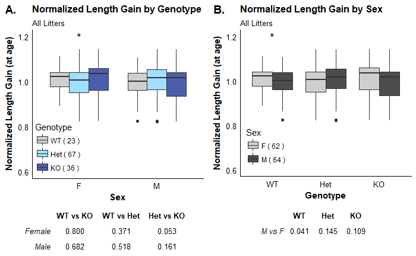

```r
#Posthoc TukeyHSD - Sex for each genotype
mod <- TukeyHSD(aov(DataF$NormAtAgeLNGain ~ DataF$Geno, data = DataF), ordered = TRUE)
Fgeno <- mod$`DataF$Geno`
mod <- TukeyHSD(aov(DataM$NormAtAgeLNGain ~ DataM$Geno, data = DataM), ordered = TRUE)
Mgeno <- mod$`DataM$Geno`
Het_KO <- c(Female = Fgeno[2,4], Male = Mgeno[2,4])
WT_KO <- c(Female = Fgeno[3,4], Male = Mgeno[3,4])
WT_Het <- c(Female = Fgeno[1,4], Male = Mgeno[1,4])
multicomp <- data.frame(WT_KO,WT_Het,Het_KO)
xaxis <- "Sex"
yaxis <- "Normalized Length Gain (at age)"
ylim <- c(0.6,1.2)
title <- "Normalized Length Gain by Genotype"
plotA <- bp(Data, x=Data$Sex, y=Data$NormAtAgeLNGain, fill=Data$Geno,
                   xaxis, yaxis, ylim, title, subtitle, color_name = "Genotype",
                   colors = geno_colors, legend_lab = geno_lab, legend_pos = c(0.15,0.2))
tableB <- ggtexttable(format(round(multicomp,3), nsmall = 3),
            cols = c("WT vs KO", "WT vs Het", "Het vs KO"),
            theme = ttheme("blank", base_size = 10))
#Posthoc TukeyHSD - Genotype for each sex
mod <- TukeyHSD(aov(DataWT$NormAtAgeLNGain ~ DataWT$Sex, data = DataWT), ordered = TRUE)
WTgeno <- mod$`DataWT$Sex`
mod <- TukeyHSD(aov(DataHet$NormAtAgeLNGain ~ DataHet$Sex, data = DataHet), ordered = TRUE)
Hetgeno <- mod$`DataHet$Sex`
mod <- TukeyHSD(aov(DataKO$NormAtAgeLNGain ~ DataKO$Sex, data = DataKO), ordered = TRUE)
KOgeno <- mod$`DataKO$Sex`
M_F <- c(WT = WTgeno[1,4], Het = Hetgeno[1,4], KO = KOgeno[1,4])
multicomp <- t(format(round(data.frame(M_F),3), nsmall = 3))
multicomp <- rbind(multicomp, c(WT = "", Het = "", KO = ""))
xaxis <- "Genotype"
title <- "Normalized Length Gain by Sex"
plotC <- bp(Data, x=Data$Geno, y=Data$NormAtAgeLNGain, fill=Data$Sex,
                   xaxis, yaxis, ylim, title, subtitle, color_name = "Sex",
                   colors = sex_colors, legend_lab = sex_lab, legend_pos = c(0.15,0.2))
tableD <- ggtexttable(multicomp,
            cols = c("WT", "Het", "KO"),
            rows = c("M vs F",""),
            theme = ttheme("blank", base_size = 10))
suppressWarnings(ggarrange(plotA, plotC, tableB, tableD, labels = c("A.","B."),
                           ncol = 2, nrow = 2, heights = c(4,1)))
```

**Normalized Length Gain - Effect of Genotype by Sex**  
For female mice, there is a trend for mutant mice (KO, *dark blue*) to have higher normalized length gain (at age) compared to heterozygous mice (Het, *light blue*; p = 0.053). There are no differences between genotypes for male mice.

**Normalized Length Gain - Effect of Sex by Genotype**  
For wildtype mice (WT), female mice gain significantly more length than male mice (p = 0.041), when the data is normalized to heterozygous mice at each age, within each litter.

### 2.3.7 Discussion

This method of normalization of measures to average heterozygous mice within each litter at each age appears to abolish the effects of genotype which are seen clearly in the data that were normalized to average measures at age 9 of heterozygous mice within each litter. Therefore, that analysis is most useful and interpretable, and should be used instead of this one.

## 2.4 Data Normalized to Average Age 9 Heterozygous Mice - Litter Sizes 2 to 5 Only

```r
#Analysis of Litter Sizes 2 - 5 Only
DataLS2to5 <- Data[which(Data$LitterSize =="2" | Data$LitterSize=="3"| Data$LitterSize=="4"| Data$LitterSize=="5"),]
DataLS2to5P3 <- DataLS2to5[which(Data$Age == "3"),]
DataLS2to5P4 <- DataLS2to5[which(Data$Age == "4"),]
DataLS2to5P5 <- DataLS2to5[which(Data$Age == "5"),]
DataLS2to5P6 <- DataLS2to5[which(Data$Age == "6"),]
DataLS2to5P7 <- DataLS2to5[which(Data$Age == "7"),]
DataLS2to5P8 <- DataLS2to5[which(Data$Age == "8"),]
DataLS2to5P9 <- DataLS2to5[which(Data$Age == "9"),]
#Creating subsets by sex
DataLS2to5F <- DataLS2to5[which(DataLS2to5$Sex == "F"),]
DataLS2to5M <- DataLS2to5[which(DataLS2to5$Sex == "M"),]
#Creating subsets by genotype
DataLS2to5WT <- DataLS2to5[which(DataLS2to5$Geno == "WT"),]
DataLS2to5Het <- DataLS2to5[which(DataLS2to5$Geno == "Het"),]
DataLS2to5KO <- DataLS2to5[which(DataLS2to5$Geno == "KO"),]
LS_lab <- c(paste("2 (",count(DataLS2to5$LitterSize[which(DataLS2to5$LitterSize == "2"
                                                    & DataLS2to5$Age == "9")])[2],")"),
            paste("3 (",count(DataLS2to5$LitterSize[which(DataLS2to5$LitterSize == "3"
                                                    & DataLS2to5$Age == "9")])[2],")"),
            paste("4 (",count(DataLS2to5$LitterSize[which(DataLS2to5$LitterSize == "4"
                                                    & DataLS2to5$Age == "9")])[2],")"),
            paste("5 (",count(DataLS2to5$LitterSize[which(DataLS2to5$LitterSize == "5"
                                                     & DataLS2to5$Age == "9")])[2],")"))
```

### 2.4.1 Normalized Weight Across Age

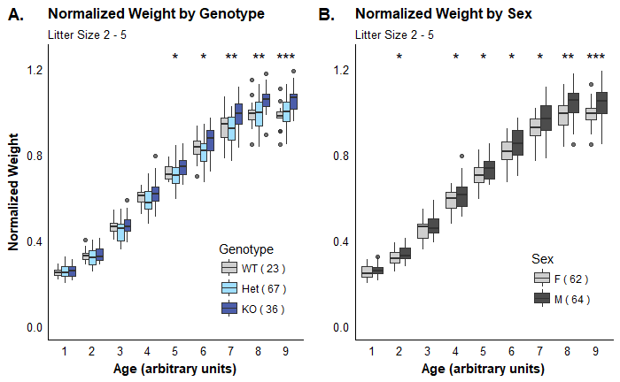

```r
#Boxplot Parameters for Norm Weight
xaxis <- "Age (arbitrary units)"
yaxis <- "Normalized Weight"
subtitle <- "Litter Size 2 - 5"
ylim <- c(0,1.25)
#Boxplot of norm weight across age, divided by genotype
title <- "Normalized Weight by Genotype"
plotA <- bp(DataLS2to5, x=DataLS2to5$AgeFactor, y=DataLS2to5$NormWT, fill=DataLS2to5$Geno,
                   xaxis, yaxis, ylim, title, subtitle, color_name = "Genotype",
                   colors = geno_colors, legend_lab = geno_lab, legend_pos = bottom_right)
#Boxplot of norm weight across age, divided by sex
title <- "Normalized Weight by Sex"
plotB <- bp(DataLS2to5, x=DataLS2to5$AgeFactor, y=DataLS2to5$NormWT, fill=DataLS2to5$Sex,
                   xaxis, yaxis="", ylim, title, subtitle, color_name = "Sex",
                   colors = sex_colors, legend_lab = sex_lab, legend_pos = bottom_right)
#Boxplot of norm weight across age, divided by litter size
title <- "Normalized Weight by Litter Size"
plotC <- brewer_bp(DataLS2to5, x=DataLS2to5$AgeFactor, y=DataLS2to5$NormWT, fill=DataLS2to5$LitterSize,
                   xaxis, yaxis, ylim, title, subtitle, color_name = "Litter Size",
                   legend_lab = LS_lab, legend_pos = "right")
#Arrange boxplots into 3 panels
suppressWarnings(ggarrange(plotA, plotB, labels = c("A.","B."), ncol = 2, nrow = 1))
```

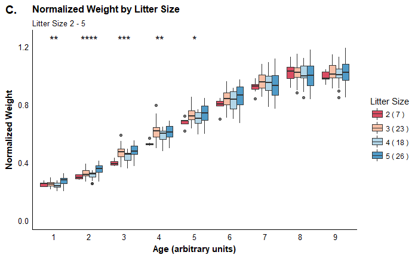

```r
suppressWarnings(ggarrange(plotC, labels = c("C."), ncol = 1, nrow = 1))
```

**Observations**

*Genotype*  
There is a significant effect of genotype on normalized weight. Post-hoc analysis are needed to determine which genotypes are different (see below).

*Sex*  
There is a significant effect of sex on normalized weight. Males are significantly larger than females.

*Litter Size*  
As expected, there is an effect of litter size at the earliest ages (artefact of normalization to average hets at age 9).

**Statistical Analyses**  
*Three Way Mixed Model ANOVA*  
*Response Variable: Normalized Weight*  
*Between Subjects Factors: Genotype, Sex*  
*Within Subjects Factors: Age*

```r
#Statistical analysis of normalized weight across age by genotype
model <- aov(DataLS2to5$NormWT ~DataLS2to5$Geno*DataLS2to5$Sex*DataLS2to5$Age +
                    Error(DataLS2to5$PupID/DataLS2to5$Age)+DataLS2to5$Geno*DataLS2to5$Sex, data=DataLS2to5)
summary(model)
```

```
Error: DataLS2to5$PupID
                               Df Sum Sq Mean Sq F value  Pr(>F)
DataLS2to5$Geno                 2 0.2173 0.10866   6.091 0.00369 **
DataLS2to5$Sex                  1 0.1038 0.10375   5.816 0.01859 *
DataLS2to5$Geno:DataLS2to5$Sex  2 0.0519 0.02596   1.455 0.24054
Residuals                      68 1.2131 0.01784
---
Signif. codes:  0 *** 0.001 ** 0.01 * 0.05 . 0.1   1

Error: DataLS2to5$PupID:DataLS2to5$Age
                                               Df Sum Sq Mean Sq  F value  Pr(>F)
DataLS2to5$Age                                  8  49.73   6.217 4869.671 < 2e-16 ***
DataLS2to5$Geno:DataLS2to5$Age                 16   0.09   0.005    4.262 7.2e-08 ***
DataLS2to5$Sex:DataLS2to5$Age                   8   0.01   0.002    1.255   0.265
DataLS2to5$Geno:DataLS2to5$Sex:DataLS2to5$Age  16   0.02   0.002    1.204   0.259
Residuals                                     544   0.69   0.001
---
Signif. codes:  0 *** 0.001 ** 0.01 * 0.05 . 0.1   1
```

There is a significant interaction between genotype and age (p < 0.0001). There is also a significant effect of sex (p = 0.019). The effect of sex would be best investigated using an aggragate measure to avoid the effect of age, such as normalized weight gain.

#### *Post-Hoc: Tukey’s Honestly Significant Difference - Genotype and Age*

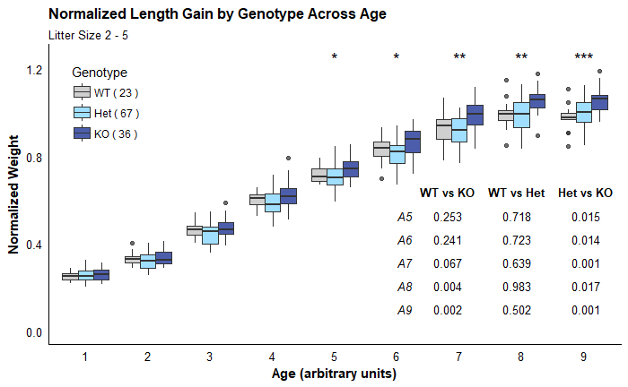

```r
#Posthoc TukeyHSD - Genotype at P5 - P9
mod <- TukeyHSD(aov(DataLS2to5P5$NormWT ~DataLS2to5P5$Geno, data = DataLS2to5P5), ordered = TRUE)
P5geno <- mod$`DataLS2to5P5$Geno`
mod <- TukeyHSD(aov(DataLS2to5P6$NormWT ~DataLS2to5P6$Geno, data = DataLS2to5P6), ordered = TRUE)
P6geno <- mod$`DataLS2to5P6$Geno`
mod <- TukeyHSD(aov(DataLS2to5P7$NormWT ~DataLS2to5P7$Geno, data = DataLS2to5P7), ordered = TRUE)
P7geno <- mod$`DataLS2to5P7$Geno`
mod <- TukeyHSD(aov(DataLS2to5P8$NormWT ~DataLS2to5P8$Geno, data = DataLS2to5P8), ordered = TRUE)
P8geno <- mod$`DataLS2to5P8$Geno`
mod <- TukeyHSD(aov(DataLS2to5P9$NormWT ~DataLS2to5P9$Geno, data = DataLS2to5P9), ordered = TRUE)
P9geno <- mod$`DataLS2to5P9$Geno`
Het_KO <- c(A5 = P5geno[2,4], A6 = P6geno[2,4], A7 = P7geno[2,4], A8 = P8geno[2,4], A9 =P9geno[2,4])
WT_KO <- c(A5 = P5geno[3,4], A6 = P6geno[3,4], A7 = P7geno[3,4], A8 = P8geno[3,4],A9 =P9geno[3,4])
WT_Het <- c(A5 = P5geno[1,4], A6 = P6geno[1,4], A7 = P7geno[1,4], A8 = P8geno[1,4],A9 =P9geno[1,4])
multicomp <- data.frame(WT_KO,WT_Het,Het_KO)
plotA <- bp(DataLS2to5, x=DataLS2to5$AgeFactor, y=DataLS2to5$NormWT, fill=DataLS2to5$Geno,
                   xaxis, yaxis, ylim, title = "Normalized Length Gain by Genotype Across Age", subtitle, color_name = "Genotype",
                   colors = geno_colors, legend_lab = geno_lab, legend_pos = c(0.1,0.8))
tableB <- ggtexttable(format(round(multicomp,3), nsmall = 3),
            cols = c("WT vs KO", "WT vs Het", "Het vs KO"),
            theme = ttheme("blank", base_size = 10))
suppressMessages(plotA + annotation_custom(ggplotGrob(tableB), xmax = 15, ymax = 0.8))
```

### 2.4.2 Normalized Length Across Age

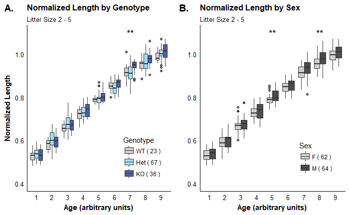

```r
#Boxplot Parameters for Norm Length
xaxis <- "Age (arbitrary units)"
yaxis <- "Normalized Length"
ylim <- c(0.4,1.1)
#Boxplot of norm Length across age, divided by genotype
title <- "Normalized Length by Genotype"
plotA <- bp(DataLS2to5, x=DataLS2to5$AgeFactor, y=DataLS2to5$NormLN, fill=DataLS2to5$Geno,
                   xaxis, yaxis, ylim, title, subtitle, color_name = "Genotype",
                   colors = geno_colors, legend_lab = geno_lab, legend_pos = bottom_right)
#Boxplot of norm Length across age, divided by sex
title <- "Normalized Length by Sex"
plotB <- bp(DataLS2to5, x=DataLS2to5$AgeFactor, y=DataLS2to5$NormLN, fill=DataLS2to5$Sex,
                   xaxis, yaxis="", ylim, title, subtitle, color_name = "Sex",
                   colors = sex_colors, legend_lab = sex_lab, legend_pos = bottom_right)
#Arrange boxplots into 3 panels
suppressWarnings(ggarrange(plotA, plotB, labels = c("A.","B."), ncol = 2, nrow = 1))
```

**Observations**

*Genotype*  
There is a significant difference in normalized mouse length between genotypes at age 7.

*Sex*  
There is a significant difference in normalized mouse length between sexes at ages 5 and 8.

**Statistical Analyses**  
*Three Way Mixed Model ANOVA*  
*Response Variable: Normalized Length*  
*Between Subjects Factors: Genotype, Sex*  
*Within Subjects Factors: Age*

```r
#Statistical analysis of normalized length across age by genotype
model <- aov(DataLS2to5$NormLN ~DataLS2to5$Geno*DataLS2to5$Sex*DataLS2to5$Age +
                    Error(DataLS2to5$PupID/DataLS2to5$Age)+DataLS2to5$Geno*DataLS2to5$Sex, data=DataLS2to5)
```

```
Error() model is singular
```

```r
summary(model)
```

```
Error: DataLS2to5$PupID
                                              Df  Sum Sq  Mean Sq F value Pr(>F)
DataLS2to5$Geno                                2 0.02777 0.013887   3.264 0.0448 *
DataLS2to5$Sex                                 1 0.02120 0.021197   4.982 0.0292 *
DataLS2to5$Age                                 1 0.00073 0.000728   0.171 0.6805
DataLS2to5$Geno:DataLS2to5$Sex                 2 0.02285 0.011427   2.685 0.0760 .
DataLS2to5$Geno:DataLS2to5$Age                 2 0.00029 0.000143   0.034 0.9671
DataLS2to5$Sex:DataLS2to5$Age                  1 0.00042 0.000417   0.098 0.7553
DataLS2to5$Geno:DataLS2to5$Sex:DataLS2to5$Age  1 0.00294 0.002940   0.691 0.4090
Residuals                                     63 0.26808 0.004255
---
Signif. codes:  0 *** 0.001 ** 0.01 * 0.05 . 0.1   1

Error: DataLS2to5$PupID:DataLS2to5$Age
                                               Df Sum Sq Mean Sq  F value  Pr(>F)
DataLS2to5$Age                                  8 16.101  2.0126 2920.907 < 2e-16 ***
DataLS2to5$Geno:DataLS2to5$Age                 16  0.025  0.0015    2.247 0.00367 **
DataLS2to5$Sex:DataLS2to5$Age                   8  0.004  0.0004    0.639 0.74502
DataLS2to5$Geno:DataLS2to5$Sex:DataLS2to5$Age  16  0.008  0.0005    0.757 0.73447
Residuals                                     536  0.369  0.0007
---
Signif. codes:  0 *** 0.001 ** 0.01 * 0.05 . 0.1   1
```

There is a significant interaction between genotype and age (p = 0.0037), as well as a significant effect of sex (p < 0.029). The effect of sex may be best described using aggragate weight measures (like weight gain or weight at age 9), rather than average across age.

#### *Post-Hoc: Tukey’s Honestly Significant Difference - Genotype and Age*

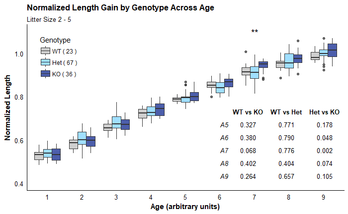

```r
#Posthoc TukeyHSD - Genotype at P5 - P9
mod <- TukeyHSD(aov(DataLS2to5P5$NormLN ~DataLS2to5P5$Geno, data = DataLS2to5P5), ordered = TRUE)
P5geno <- mod$`DataLS2to5P5$Geno`
mod <- TukeyHSD(aov(DataLS2to5P6$NormLN ~DataLS2to5P6$Geno, data = DataLS2to5P6), ordered = TRUE)
P6geno <- mod$`DataLS2to5P6$Geno`
mod <- TukeyHSD(aov(DataLS2to5P7$NormLN ~DataLS2to5P7$Geno, data = DataLS2to5P7), ordered = TRUE)
P7geno <- mod$`DataLS2to5P7$Geno`
mod <- TukeyHSD(aov(DataLS2to5P8$NormLN ~DataLS2to5P8$Geno, data = DataLS2to5P8), ordered = TRUE)
P8geno <- mod$`DataLS2to5P8$Geno`
mod <- TukeyHSD(aov(DataLS2to5P9$NormLN ~DataLS2to5P9$Geno, data = DataLS2to5P9), ordered = TRUE)
P9geno <- mod$`DataLS2to5P9$Geno`
Het_KO <- c(A5 = P5geno[2,4], A6 = P6geno[2,4], A7 = P7geno[2,4], A8 = P8geno[2,4], A9 =P9geno[2,4])
WT_KO <- c(A5 = P5geno[3,4], A6 = P6geno[3,4], A7 = P7geno[3,4], A8 = P8geno[3,4],A9 =P9geno[3,4])
WT_Het <- c(A5 = P5geno[1,4], A6 = P6geno[1,4], A7 = P7geno[1,4], A8 = P8geno[1,4],A9 =P9geno[1,4])
multicomp <- data.frame(WT_KO,WT_Het,Het_KO)
plotA <- bp(DataLS2to5, x=DataLS2to5$AgeFactor, y=DataLS2to5$NormLN, fill=DataLS2to5$Geno,
                   xaxis, yaxis, ylim, title = "Normalized Length Gain by Genotype Across Age", subtitle, color_name = "Genotype",
                   colors = geno_colors, legend_lab = geno_lab, legend_pos = c(0.1,0.8))
tableB <- ggtexttable(format(round(multicomp,3), nsmall = 3),
            cols = c("WT vs KO", "WT vs Het", "Het vs KO"),
            theme = ttheme("blank", base_size = 10))
suppressMessages(plotA + annotation_custom(ggplotGrob(tableB), xmax = 15, ymax = 0.8))
```

Post-hoc analyses reveal that mutant mice (KO, *dark blue*) are significantly longer than heterozygous mice (Het, *light blue*, age 6 - 7, p < 0.05), and show a trend towards being longer than wildtype mice (WT, *grey*, age 7, p = 0.068). There is no significant difference in weight between wildtype and heterozygous mice at any age. Mutant mice are not significantly different from either heterozyous or wildtype mice at age 9 likely due to the high variability in the data at this age.

### 2.4.3 Normalized BMI Across Age

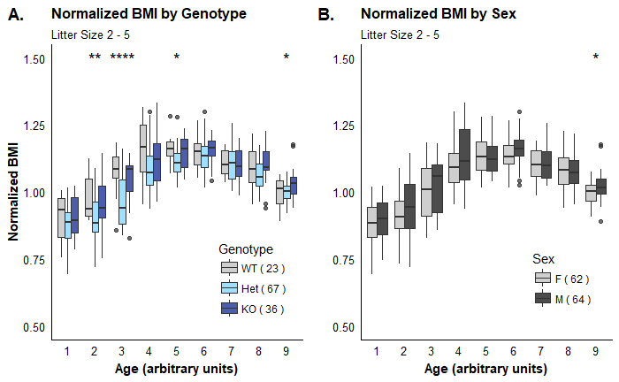

```r
#Boxplot Parameters for Norm BMI
xaxis <- "Age (arbitrary units)"
yaxis <- "Normalized BMI"
ylim <- c(0.5, 1.5)
#Boxplot of norm BMI across age, divided by genotype
title <- "Normalized BMI by Genotype"
plotA <- bp(DataLS2to5, x=DataLS2to5$AgeFactor, y=DataLS2to5$NormBMI, fill=DataLS2to5$Geno,
                   xaxis, yaxis, ylim, title, subtitle, color_name = "Genotype",
                   colors = geno_colors, legend_lab = geno_lab, legend_pos = bottom_right)
#Boxplot of norm BMI across age, divided by sex
title <- "Normalized BMI by Sex"
plotB <- bp(DataLS2to5, x=DataLS2to5$AgeFactor, y=DataLS2to5$NormBMI, fill=DataLS2to5$Sex,
                   xaxis, yaxis="", ylim, title, subtitle, color_name = "Sex",
                   colors = sex_colors, legend_lab = sex_lab, legend_pos = bottom_right)
#Arrange boxplots into 3 panels
suppressWarnings(ggarrange(plotA, plotB, labels = c("A.","B."), ncol = 2, nrow = 1))
```

**Observations**

```r
#Statistical analysis of normalized length across age by genotype
model <- aov(DataLS2to5$NormBMI ~DataLS2to5$Geno*DataLS2to5$Sex*DataLS2to5$Age +
                    Error(DataLS2to5$PupID/DataLS2to5$Age)+DataLS2to5$Geno*DataLS2to5$Sex, data=DataLS2to5)
```

```
Error() model is singular
```

```r
summary(model)
```

```
Error: DataLS2to5$PupID
                                              Df Sum Sq Mean Sq F value  Pr(>F)
DataLS2to5$Geno                                2 0.2619 0.13097   5.889 0.00452 **
DataLS2to5$Sex                                 1 0.0148 0.01480   0.665 0.41773
DataLS2to5$Age                                 1 0.0001 0.00010   0.005 0.94562
DataLS2to5$Geno:DataLS2to5$Sex                 2 0.0087 0.00435   0.196 0.82282
DataLS2to5$Geno:DataLS2to5$Age                 2 0.0465 0.02326   1.046 0.35737
DataLS2to5$Sex:DataLS2to5$Age                  1 0.0336 0.03358   1.510 0.22371
DataLS2to5$Geno:DataLS2to5$Sex:DataLS2to5$Age  1 0.0005 0.00054   0.024 0.87612
Residuals                                     63 1.4011 0.02224
---
Signif. codes:  0 *** 0.001 ** 0.01 * 0.05 . 0.1   1

Error: DataLS2to5$PupID:DataLS2to5$Age
                                               Df Sum Sq Mean Sq F value   Pr(>F)
DataLS2to5$Age                                  8  4.809  0.6011 170.454  < 2e-16 ***
DataLS2to5$Geno:DataLS2to5$Age                 16  0.175  0.0109   3.103 4.59e-05 ***
DataLS2to5$Sex:DataLS2to5$Age                   8  0.022  0.0028   0.789    0.612
DataLS2to5$Geno:DataLS2to5$Sex:DataLS2to5$Age  16  0.062  0.0038   1.091    0.360
Residuals                                     536  1.890  0.0035
---
Signif. codes:  0 *** 0.001 ** 0.01 * 0.05 . 0.1   1
```

There is a significant interaction between genotype and age (p < 0.0001).

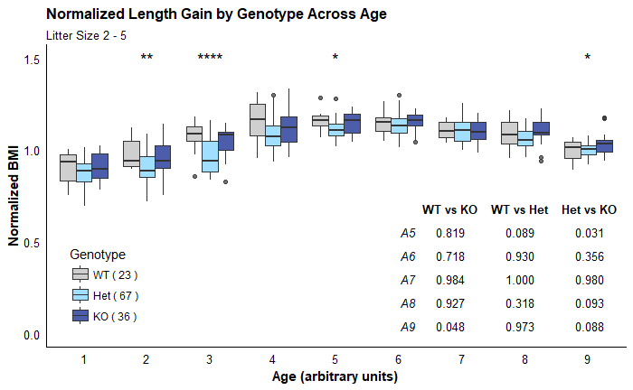

```r
ylim <- c(0, 1.5)
#Posthoc TukeyHSD - Genotype at P5 - P9
mod <- TukeyHSD(aov(DataLS2to5P5$NormBMI ~DataLS2to5P5$Geno, data = DataLS2to5P5), ordered = TRUE)
P5geno <- mod$`DataLS2to5P5$Geno`
mod <- TukeyHSD(aov(DataLS2to5P6$NormBMI ~DataLS2to5P6$Geno, data = DataLS2to5P6), ordered = TRUE)
P6geno <- mod$`DataLS2to5P6$Geno`
mod <- TukeyHSD(aov(DataLS2to5P7$NormBMI ~DataLS2to5P7$Geno, data = DataLS2to5P7), ordered = TRUE)
P7geno <- mod$`DataLS2to5P7$Geno`
mod <- TukeyHSD(aov(DataLS2to5P8$NormBMI ~DataLS2to5P8$Geno, data = DataLS2to5P8), ordered = TRUE)
P8geno <- mod$`DataLS2to5P8$Geno`
mod <- TukeyHSD(aov(DataLS2to5P9$NormBMI ~DataLS2to5P9$Geno, data = DataLS2to5P9), ordered = TRUE)
P9geno <- mod$`DataLS2to5P9$Geno`
Het_KO <- c(A5 = P5geno[2,4], A6 = P6geno[2,4], A7 = P7geno[2,4], A8 = P8geno[2,4], A9 =P9geno[2,4])
WT_KO <- c(A5 = P5geno[3,4], A6 = P6geno[3,4], A7 = P7geno[3,4], A8 = P8geno[3,4],A9 =P9geno[3,4])
WT_Het <- c(A5 = P5geno[1,4], A6 = P6geno[1,4], A7 = P7geno[1,4], A8 = P8geno[1,4],A9 =P9geno[1,4])
multicomp <- data.frame(WT_KO,WT_Het,Het_KO)
plotA <- bp(DataLS2to5, x=DataLS2to5$AgeFactor, y=DataLS2to5$NormBMI, fill=DataLS2to5$Geno,
                   xaxis, yaxis, ylim, title = "Normalized Length Gain by Genotype Across Age", subtitle, color_name = "Genotype",
                   colors = geno_colors, legend_lab = geno_lab, legend_pos = c(0.1,0.2))
tableB <- ggtexttable(format(round(multicomp,3), nsmall = 3),
            cols = c("WT vs KO", "WT vs Het", "Het vs KO"),
            theme = ttheme("blank", base_size = 10))
suppressMessages(plotA + annotation_custom(ggplotGrob(tableB), xmax = 15, ymax = 0.8))
```

### 2.4.4 Normalized Weight Gain, Normalized Length Gain and Normalized BMI (Age 9) Across Litter Size

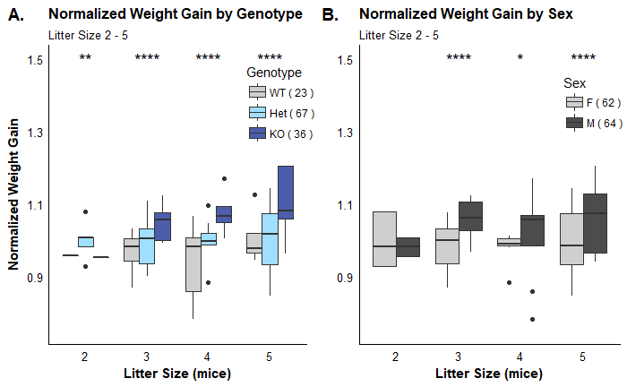

```r
#Boxplot Parameters for Normalized Weight Gain
xaxis <- "Litter Size (mice)"
yaxis <- "Normalized Weight Gain"
ylim <- c(0.75,1.5)
#Boxplot of norm weight gain across age, divided by genotype
title <- "Normalized Weight Gain by Genotype"
plotA <- bp(DataLS2to5, x=DataLS2to5$LitterSize, y=DataLS2to5$NormWTGain, fill=DataLS2to5$Geno,
                   xaxis, yaxis, ylim, title, subtitle, color_name = "Genotype",
                   colors = geno_colors, legend_lab = geno_lab, legend_pos = top_right)
#Boxplot of norm weight gain across age, divided by sex
title <- "Normalized Weight Gain by Sex"
plotB <- bp(DataLS2to5, x=DataLS2to5$LitterSize, y=DataLS2to5$NormWTGain, fill=DataLS2to5$Sex,
                   xaxis, yaxis="", ylim, title, subtitle, color_name = "Sex",
                   colors = sex_colors, legend_lab = sex_lab, legend_pos = top_right)
#Boxplot Parameters - Boxplots for Length Gain
yaxis <- "Normalized Length Gain"
ylim <- c(0.75,1.5)
#Boxplot of norm length gain across age, divided by genotype
title <- "Normalized Length Gain by Genotype"
plotC <- bp(DataLS2to5, x=DataLS2to5$LitterSize, y=DataLS2to5$NormLNGain, fill=DataLS2to5$Geno,
                   xaxis, yaxis, ylim, title, subtitle, color_name = "Genotype",
                   colors = geno_colors, legend_lab = geno_lab, legend_pos = top_right)
#Boxplot of norm length gain across age, divided by sex
title <- "Normalized Length Gain by Sex"
plotD <- bp(DataLS2to5, x=DataLS2to5$LitterSize, y=DataLS2to5$NormLNGain, fill=DataLS2to5$Sex,
                   xaxis, yaxis="", ylim, title, subtitle, color_name = "Sex",
                   colors = sex_colors, legend_lab = sex_lab, legend_pos = top_right)
#Boxplot Parameters - Boxplots for BMI atage 9
yaxis <- "Normalized BMI atage 9"
ylim <- c(1.75,4.25)
#Boxplot of norm BMI atage 9 across age, divided by genotype
title <- "Normalized BMI atage 9 by Genotype"
plotE <- bp(DataLS2to5, x=DataLS2to5$LitterSize, y=DataLS2to5$BMI, fill=DataLS2to5$Geno,
                   xaxis, yaxis, ylim, title, subtitle, color_name = "Genotype",
                   colors = geno_colors, legend_lab = geno_lab, legend_pos = top_right)
#Boxplot of norm BMI atage 9 across age, divided by sex
title <- "Normalized BMI atage 9 by Sex"
plotF <- bp(DataLS2to5, x=DataLS2to5$LitterSize, y=DataLS2to5$BMI, fill=DataLS2to5$Sex,
                   xaxis, yaxis="", ylim, title, subtitle, color_name = "Sex",
                   colors = sex_colors, legend_lab = sex_lab, legend_pos = top_right)
suppressWarnings(ggarrange(plotA, plotB, labels = c("A.","B."), ncol = 2, nrow = 1))
```

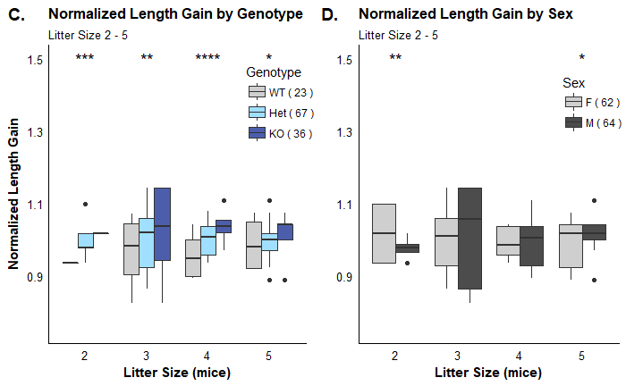

```r
suppressWarnings(ggarrange(plotC, plotD, labels = c("C.","D."), ncol = 2, nrow = 1))
```

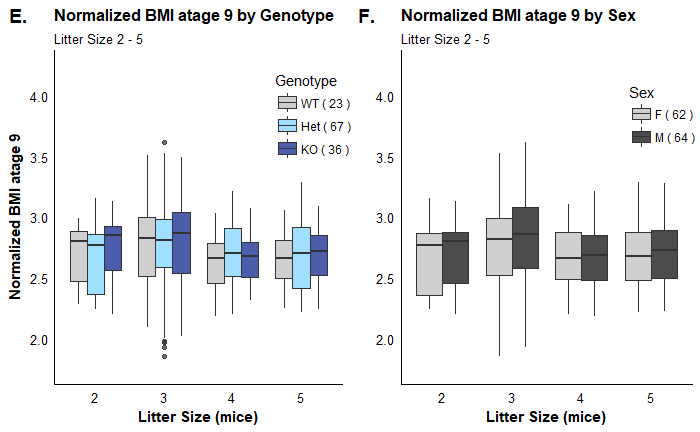

```r
suppressWarnings(ggarrange(plotE, plotF, labels = c("E.","F."), ncol = 2, nrow = 1))
```

**Observations**  
There is a strong effect of genotype and sex for both normalized weight gain and normalized length gain, but not normalized BMI.

### 2.4.5 Statistical Analysis of Normalized Weight Gain

*Two Way ANOVA*  
*Response Variable: Normalized Weight Gain*  
*Between Subjects Factors: Genotype, Sex*

```r
#Statistical analysis of normalized weight gain by genotype and sex
model <- aov(DataLS2to5$NormWTGain ~DataLS2to5$Geno*DataLS2to5$Sex, data=DataLS2to5)
summary(model)
```

```
                                Df Sum Sq Mean Sq F value   Pr(>F)
DataLS2to5$Geno                  2 0.8587  0.4293   91.92  < 2e-16 ***
DataLS2to5$Sex                   1 0.2416  0.2416   51.72 1.74e-12 ***
DataLS2to5$Geno:DataLS2to5$Sex   2 0.1935  0.0967   20.71 1.89e-09 ***
Residuals                      660 3.0827  0.0047
---
Signif. codes:  0 *** 0.001 ** 0.01 * 0.05 . 0.1   1
```

There is a significant interaction between genotype and sex (p < 0.0001).

#### *Post-Hoc: Tukey’s Honestly Significant Difference - Genotype and Sex*

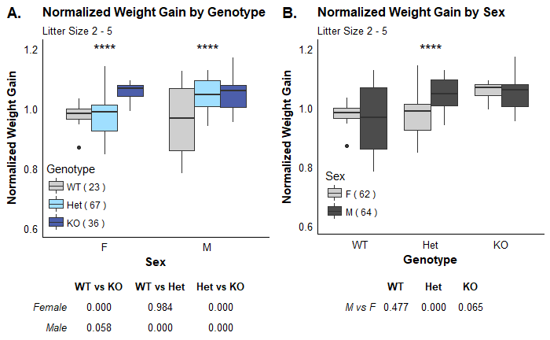

```r
#Posthoc TukeyHSD - Sex for each genotype
mod <- TukeyHSD(aov(DataLS2to5F$NormWTGain ~ DataLS2to5F$Geno, data = DataLS2to5F), ordered = TRUE)
Fgeno <- mod$`DataLS2to5F$Geno`
mod <- TukeyHSD(aov(DataLS2to5M$NormWTGain ~ DataLS2to5M$Geno, data = DataLS2to5M), ordered = TRUE)
Mgeno <- mod$`DataLS2to5M$Geno`
Het_KO <- c(Female = Fgeno[2,4], Male = Mgeno[2,4])
WT_KO <- c(Female = Fgeno[3,4], Male = Mgeno[3,4])
WT_Het <- c(Female = Fgeno[1,4], Male = Mgeno[1,4])
multicomp <- data.frame(WT_KO,WT_Het,Het_KO)
xaxis <- "Sex"
yaxis <- "Normalized Weight Gain"
ylim <- c(0.6,1.2)
title <- "Normalized Weight Gain by Genotype"
plotA <- bp(DataLS2to5, x=DataLS2to5$Sex, y=DataLS2to5$NormWTGain, fill=DataLS2to5$Geno,
                   xaxis, yaxis, ylim, title, subtitle, color_name = "Genotype",
                   colors = geno_colors, legend_lab = geno_lab, legend_pos = c(0.15,0.2))
tableB <- ggtexttable(format(round(multicomp,3), nsmall = 3),
            cols = c("WT vs KO", "WT vs Het", "Het vs KO"),
            theme = ttheme("blank", base_size = 10))
#Posthoc TukeyHSD - Genotype for each sex
mod <- TukeyHSD(aov(DataLS2to5WT$NormWTGain ~ DataLS2to5WT$Sex, data = DataLS2to5WT), ordered = TRUE)
WTgeno <- mod$`DataLS2to5WT$Sex`
mod <- TukeyHSD(aov(DataLS2to5Het$NormWTGain ~ DataLS2to5Het$Sex, data = DataLS2to5Het), ordered = TRUE)
Hetgeno <- mod$`DataLS2to5Het$Sex`
mod <- TukeyHSD(aov(DataLS2to5KO$NormWTGain ~ DataLS2to5KO$Sex, data = DataLS2to5KO), ordered = TRUE)
KOgeno <- mod$`DataLS2to5KO$Sex`
M_F <- c(WT = WTgeno[1,4], Het = Hetgeno[1,4], KO = KOgeno[1,4])
multicomp <- t(format(round(data.frame(M_F),3), nsmall = 3))
multicomp <- rbind(multicomp, c(WT = "", Het = "", KO = ""))
xaxis <- "Genotype"
title <- "Normalized Weight Gain by Sex"
plotC <- bp(DataLS2to5, x=DataLS2to5$Geno, y=DataLS2to5$NormWTGain, fill=DataLS2to5$Sex,
                   xaxis, yaxis, ylim, title, subtitle, color_name = "Sex",
                   colors = sex_colors, legend_lab = sex_lab, legend_pos = c(0.15,0.2))
tableD <- ggtexttable(multicomp,
            cols = c("WT", "Het", "KO"),
            rows = c("M vs F",""),
            theme = ttheme("blank", base_size = 10))
suppressWarnings(ggarrange(plotA, plotC, tableB, tableD, labels = c("A.","B."),
                           ncol = 2, nrow = 2, heights = c(4,1)))
```

**Normalized Weight Gain - Effect of Genotype by Sex**  
For female mice, mutant mice (KO, *dark blue*) gain significantly more weight than either heterozygous (Het, *light blue*, p < 0.0001) or wildtype mice (WT, *grey*, p < 0.0001), which are not different from one another.

**Normalized Weight Gain - Effect of Sex by Genotype**  
For wildtype and mutant mice, there is not effect of sex on normalized weight gain. For heterozygous mice, males gain significantly more weight than females.

### 2.4.6 Statistical Analysis of Normalized Length Gain

*Two Way ANOVA*  
*Response Variable: Normalized Length Gain*  
*Between Subjects Factors: Genotype, Sex*

```r
#Statistical analysis of normalized length gain by genotype and sex
model <- aov(DataLS2to5$NormLNGain ~DataLS2to5$Geno*DataLS2to5$Sex, data=DataLS2to5)
summary(model)
```

```
                                Df Sum Sq Mean Sq F value   Pr(>F)
DataLS2to5$Geno                  2 0.2933 0.14663  31.522 8.42e-14 ***
DataLS2to5$Sex                   1 0.0004 0.00044   0.095    0.758
DataLS2to5$Geno:DataLS2to5$Sex   2 0.4043 0.20214  43.456  < 2e-16 ***
Residuals                      660 3.0701 0.00465
---
Signif. codes:  0 *** 0.001 ** 0.01 * 0.05 . 0.1   1
```

There is a significant interaction between genotype and sex (p < 0.0001).

#### *Post-Hoc: Tukey’s Honestly Significant Difference - Genotype and Sex*

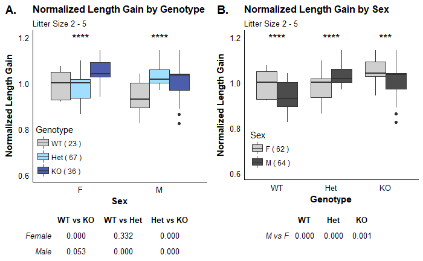

```r
#Posthoc TukeyHSD - Sex for each genotype
mod <- TukeyHSD(aov(DataLS2to5F$NormLNGain ~ DataLS2to5F$Geno, data = DataLS2to5F), ordered = TRUE)
Fgeno <- mod$`DataLS2to5F$Geno`
mod <- TukeyHSD(aov(DataLS2to5M$NormLNGain ~ DataLS2to5M$Geno, data = DataLS2to5M), ordered = TRUE)
Mgeno <- mod$`DataLS2to5M$Geno`
Het_KO <- c(Female = Fgeno[2,4], Male = Mgeno[2,4])
WT_KO <- c(Female = Fgeno[3,4], Male = Mgeno[3,4])
WT_Het <- c(Female = Fgeno[1,4], Male = Mgeno[1,4])
multicomp <- data.frame(WT_KO,WT_Het,Het_KO)
xaxis <- "Sex"
yaxis <- "Normalized Length Gain"
ylim <- c(0.6,1.2)
title <- "Normalized Length Gain by Genotype"
plotA <- bp(DataLS2to5, x=DataLS2to5$Sex, y=DataLS2to5$NormLNGain, fill=DataLS2to5$Geno,
                   xaxis, yaxis, ylim, title, subtitle, color_name = "Genotype",
                   colors = geno_colors, legend_lab = geno_lab, legend_pos = c(0.15,0.2))
tableB <- ggtexttable(format(round(multicomp,3), nsmall = 3),
            cols = c("WT vs KO", "WT vs Het", "Het vs KO"),
            theme = ttheme("blank", base_size = 10))
#Posthoc TukeyHSD - Genotype for each sex
mod <- TukeyHSD(aov(DataLS2to5WT$NormLNGain ~ DataLS2to5WT$Sex, data = DataLS2to5WT), ordered = TRUE)
WTgeno <- mod$`DataLS2to5WT$Sex`
mod <- TukeyHSD(aov(DataLS2to5Het$NormLNGain ~ DataLS2to5Het$Sex, data = DataLS2to5Het), ordered = TRUE)
Hetgeno <- mod$`DataLS2to5Het$Sex`
mod <- TukeyHSD(aov(DataLS2to5KO$NormLNGain ~ DataLS2to5KO$Sex, data = DataLS2to5KO), ordered = TRUE)
KOgeno <- mod$`DataLS2to5KO$Sex`
M_F <- c(WT = WTgeno[1,4], Het = Hetgeno[1,4], KO = KOgeno[1,4])
multicomp <- t(format(round(data.frame(M_F),3), nsmall = 3))
multicomp <- rbind(multicomp, c(WT = "", Het = "", KO = ""))
xaxis <- "Genotype"
title <- "Normalized Length Gain by Sex"
plotC <- bp(DataLS2to5, x=DataLS2to5$Geno, y=DataLS2to5$NormLNGain, fill=DataLS2to5$Sex,
                   xaxis, yaxis, ylim, title, subtitle, color_name = "Sex",
                   colors = sex_colors, legend_lab = sex_lab, legend_pos = c(0.15,0.2))
tableD <- ggtexttable(multicomp,
            cols = c("WT", "Het", "KO"),
            rows = c("M vs F",""),
            theme = ttheme("blank", base_size = 10))
suppressWarnings(ggarrange(plotA, plotC, tableB, tableD, labels = c("A.","B."),
                           ncol = 2, nrow = 2, heights = c(4,1)))
```

**Normalized Length Gain - Effect of Genotype by Sex**  
For female mice, mutant mice (KO, *dark blue*) gain significantly more length than either heterozygous (Het, *light blue*, p < 0.0001) or wildtype mice (WT, *grey*, p < 0.0001), which are not different from one another.

For male mice, heterozygous (Het, *light blue*) mice gained significantly more length than either wildtype (WT, *grey*, p < 0.0001) or mutant (KO, *dark blue*, p < 0.0001) mice. There was a trend towards mutant mice gaining significantly more length than wildtype mice (p = 0.053), however, this difference likely failed to reach significance due to mutant outliers.

**Normalized Length Gain - Effect of Sex by Genotype**  
For wildtype and mutant mice, female mice gained significantly more length than male mice. For heterozygous mice, males gain significantly more length than females.

### 2.4.7 Statistical Analysis of Normalized BMI at Age 9

*Two Way ANOVA*  
*Response Variable: Normalized BMI at age 9*  
*Between Subjects Factors: Genotype, Sex*

```r
#Statistical analysis of normalized BMI atage 9 genotype
model <- aov(DataLS2to5P9$NormBMI ~DataLS2to5P9$Geno*DataLS2to5P9$Sex, data=DataLS2to5P9)
summary(model)
```

```
                                   Df  Sum Sq  Mean Sq F value Pr(>F)
DataLS2to5P9$Geno                   2 0.01671 0.008356   3.605 0.0325 *
DataLS2to5P9$Sex                    1 0.00810 0.008100   3.495 0.0659 .
DataLS2to5P9$Geno:DataLS2to5P9$Sex  2 0.00430 0.002149   0.927 0.4007
Residuals                          68 0.15762 0.002318
---
Signif. codes:  0 *** 0.001 ** 0.01 * 0.05 . 0.1   1
52 observations deleted due to missingness
```

There was a significant effect of genotype on normalized BMI at Age 9.

#### *Post-Hoc: Tukey’s Honestly Significant Difference - Genotype*

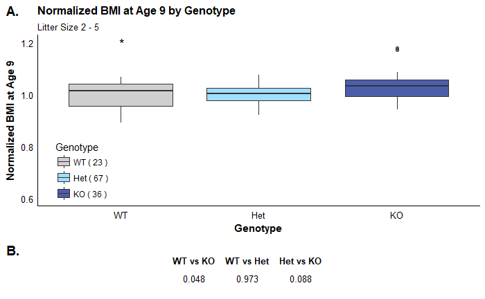

```r
DataLS2to5P9 <- DataLS2to5P9[complete.cases(DataLS2to5P9$NormBMI),]
#Posthoc TukeyHSD
mod <- TukeyHSD(aov(DataLS2to5P9$NormBMI ~ DataLS2to5P9$Geno, data = DataLS2to5P9), ordered = TRUE)
Geno <- mod$`DataLS2to5P9$Geno`
Het_KO <- Geno[2,4]
WT_KO <- Geno[3,4]
WT_Het <- Geno[1,4]
multicomp <- data.frame(WT_KO,WT_Het,Het_KO)
xaxis <- "Genotype"
yaxis <- "Normalized BMI at Age 9"
ylim <- c(0.6,1.2)
title <- "Normalized BMI at Age 9 by Genotype"
plotA <- bp(DataLS2to5P9, x=DataLS2to5P9$Geno, y=DataLS2to5P9$NormBMI, fill=DataLS2to5P9$Geno,
                   xaxis, yaxis, ylim, title, subtitle, color_name = "Genotype",
                   colors = geno_colors, legend_lab = geno_lab, legend_pos = c(0.1,0.2))
tableB <- ggtexttable(format(round(multicomp,3), nsmall = 3),
            cols = c("WT vs KO", "WT vs Het", "Het vs KO"),
            rows = c(""),
            theme = ttheme("blank", base_size = 10))
ggarrange(plotA, tableB, labels = c("A.","B."), ncol = 1, nrow = 2, heights = c(4,1))
```

Posthoc analyses reveal that mutant mice (KO, *dark blue*) have significantly greater normalized BMI at age 9 as compared to wildtype mice (WT, *grey*, p = 0.048). There is no significant difference in normalized BMI at age 9 between heterozygous mice (Het, *light blue*) and wildtype mice (p = 0.973). There is a trend towards mutant mice having greater normalized BMI at age 9 as compared to heterozygous mice (p = 0.088).